# Basic loops

Min-Yao

2021-03-03

## Learning Goals

*At the end of this exercise, you will be able to:*  
1. know the concept of loops. 2. understand the three different types of loops. 3. use loops in vectors and data frames. 4. use loops through multiple files and create a summary.

## Resources and references

- [Statistics Globe](https://statisticsglobe.com/loops-in-r/)
- [R - Loops](https://www.tutorialspoint.com/r/r_loops.htm)
- [Data Carpentry for Biologists](https://datacarpentry.org/semester-biology/materials/for-loops-R/)
- [Data Carpentry](https://github.com/datacarpentry/semester-biology)
- [Data Science in Omics Introduction](https://hoytpr.github.io/bioinformatics-semester/)

## Load the libraries

```r
library(tidyverse)
library(ggmap)
library(lubridate)
```

## What Are Loops?

A loop is a programming instruction that repeats until a specific condition is reached. Each time the code block within the loop is executed is called an iteration. *Different Types of Loops:* Depending on your specific programming situation, you may need different loop-structures that execute the code blocks within the loop on the basis of different conditions. The R programming language generally provides three different types of loops: 1. Repeat-loops, 2. While-loops, 3. For-loops

## Repeat-Loops

Repeat-loops repeat a code block until a break condition is fulfilled. This break condition marks the end of the loop.

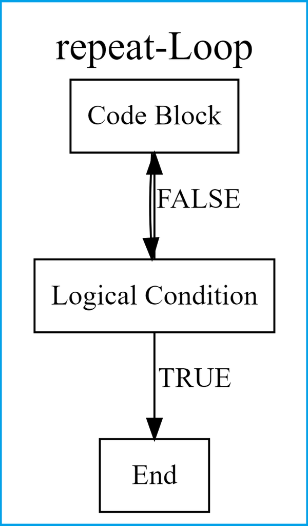

Repeats until breaking condition is filled. Logical condition tells the computer what the break condition is. Once true, the loop will break and the code will end.

### Syntax of repeat loop

```r
repeat {
   commands
   if(condition) {
      break
   }
}
```

### example 0: Writing a repeat-Loop in R (Basics)

```r
x <- 0                 # Preliminary specification of data object
repeat{                # Head of repeat-loop
  x <- x + 1           # Body of repeat-loop
  print(x)
  if(x >= 10) {        # Break condition of repeat-loop. "Repeat process until x >= 10
    break
  }
}
```

```
## [1] 1
## [1] 2
## [1] 3
## [1] 4
## [1] 5
## [1] 6
## [1] 7
## [1] 8
## [1] 9
## [1] 10
```

### example 1: repeat-Loop Through Columns of Data Frame

```r
data <- data.frame(x1 = 1:5,      # Create example data
                   x2 = 6:10,
                   x3 = 11:15)
data
```

```
##   x1 x2 x3
## 1  1  6 11
## 2  2  7 12
## 3  3  8 13
## 4  4  9 14
## 5  5 10 15
```

```r
data1 <- data                   # Replicate example data
i <- 1                          # Create running index (It's like an x in the previous example)
repeat{                         # Start repeat-loop
  data1[ , i] <- data1[ , i] + 100  #Taking value inside [] is specific value of data frame. Store that value +100 into new value as a new column.
  i <- i + 1
  if(i > 2) {
    break
  }
}
data1
```

```
##    x1  x2 x3
## 1 101 106 11
## 2 102 107 12
## 3 103 108 13
## 4 104 109 14
## 5 105 110 15
```

### Practice: Please write a repeat loop to change all numeric data from in centimeters to millimeters.

```r
#?iris
data(iris)                          # Loading data frame
head(iris)                          # Head of example data
```

```
##   Sepal.Length Sepal.Width Petal.Length Petal.Width Species
## 1          5.1         3.5          1.4         0.2  setosa
## 2          4.9         3.0          1.4         0.2  setosa
## 3          4.7         3.2          1.3         0.2  setosa
## 4          4.6         3.1          1.5         0.2  setosa
## 5          5.0         3.6          1.4         0.2  setosa
## 6          5.4         3.9          1.7         0.4  setosa
```

```r
iris1 <- iris                       # Replicate example data

i <- 1
repeat{
  iris1[ , i] <- iris1[ , i] * 10
  i <- i + 1
  if(!is.numeric(iris1[ , i])){
    break
  }
}
head(iris1)
```

```
##   Sepal.Length Sepal.Width Petal.Length Petal.Width Species
## 1           51          35           14           2  setosa
## 2           49          30           14           2  setosa
## 3           47          32           13           2  setosa
## 4           46          31           15           2  setosa
## 5           50          36           14           2  setosa
## 6           54          39           17           4  setosa
```

[output not shown]

### example 0: Writing while-Loop in R (Basics)

```r
x <- 0                  # Preliminary specification of data object
while(x < 10) {         # Head of while-loop
  x <- x + 1            # Body of while-loop
  print(x)
}
```

```
## [1] 1
## [1] 2
## [1] 3
## [1] 4
## [1] 5
## [1] 6
## [1] 7
## [1] 8
## [1] 9
## [1] 10
```

### example 1: while-Loop Through Columns of Data Frame

```r
data2 <- data                       # Replicate example data
data2
```

```
##   x1 x2 x3
## 1  1  6 11
## 2  2  7 12
## 3  3  8 13
## 4  4  9 14
## 5  5 10 15
```

```r
i <- 1                              # Create running index. Assigning i as 1
while(i <= 2) {                     # Start while-loop. Condition i is <=2
  data2[ , i] <- data2[ , i] + 100
  i <- i + 1
}
data2
```

```
##    x1  x2 x3
## 1 101 106 11
## 2 102 107 12
## 3 103 108 13
## 4 104 109 14
## 5 105 110 15
```

### Practice: Please write a while loop to change all numeric data from in centimeters to millimeters.

```r
head(iris)                                        # Showing head of data in RStudio console
```

```
##   Sepal.Length Sepal.Width Petal.Length Petal.Width Species
## 1          5.1         3.5          1.4         0.2  setosa
## 2          4.9         3.0          1.4         0.2  setosa
## 3          4.7         3.2          1.3         0.2  setosa
## 4          4.6         3.1          1.5         0.2  setosa
## 5          5.0         3.6          1.4         0.2  setosa
## 6          5.4         3.9          1.7         0.4  setosa
```

```r
iris2 <- iris                                     # Replicate example data

i <- 1
while(is.numeric(iris2[ , i])){
  iris2[ , i] <- iris2[ , i] * 10
  i <- i + 1
}
head(iris2)
```

```
##   Sepal.Length Sepal.Width Petal.Length Petal.Width Species
## 1           51          35           14           2  setosa
## 2           49          30           14           2  setosa
## 3           47          32           13           2  setosa
## 4           46          31           15           2  setosa
## 5           50          36           14           2  setosa
## 6           54          39           17           4  setosa
```

## For-Loops

For-loops specify a collection of objects (e.g. elements in a vector or list) to which a code block should be applied.

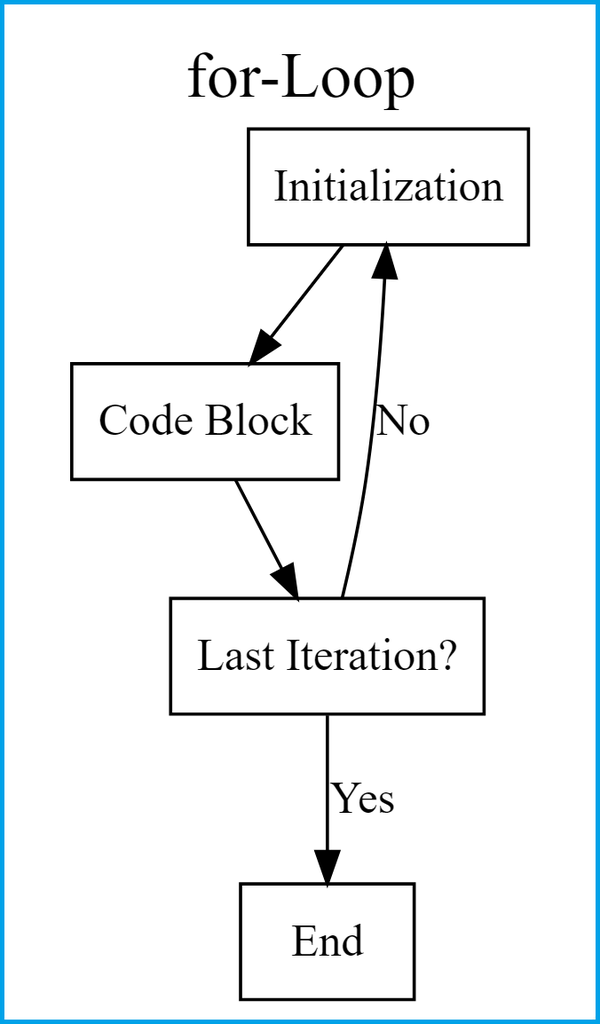

### Syntax of for loop

```r
for (value in vector) {
   statements
}
```

### example 0: Loop Through Vector in R (Basics)

```r
for (i in 1:10) { #Running index i in vector 1 to 1
  print(i)
}
```

```
## [1] 1
## [1] 2
## [1] 3
## [1] 4
## [1] 5
## [1] 6
## [1] 7
## [1] 8
## [1] 9
## [1] 10
```

### example 1: For-Loop Through Columns of Data Frame

```r
data3 <- data                       # Replicate example data
data3
```

```
##   x1 x2 x3
## 1  1  6 11
## 2  2  7 12
## 3  3  8 13
## 4  4  9 14
## 5  5 10 15
```

```r
for(i in 1:2) {           # for-loop over columns
  data3[ , i] <- data3[ , i] + 100
}
data3
```

```
##    x1  x2 x3
## 1 101 106 11
## 2 102 107 12
## 3 103 108 13
## 4 104 109 14
## 5 105 110 15
```

### Practice 1: Please write a for loop to change only width data from in centimeters to millimeters.

```r
head(iris)                                             # Inspecting iris flower data set
```

```
##   Sepal.Length Sepal.Width Petal.Length Petal.Width Species
## 1          5.1         3.5          1.4         0.2  setosa
## 2          4.9         3.0          1.4         0.2  setosa
## 3          4.7         3.2          1.3         0.2  setosa
## 4          4.6         3.1          1.5         0.2  setosa
## 5          5.0         3.6          1.4         0.2  setosa
## 6          5.4         3.9          1.7         0.4  setosa
```

```r
iris3 <- iris                                          # Replicate iris data set

for(i in c(2,4)){
  iris3[ , i] <- iris3[ , i] * 10
}
head(iris3)
```

```
##   Sepal.Length Sepal.Width Petal.Length Petal.Width Species
## 1          5.1          35          1.4           2  setosa
## 2          4.9          30          1.4           2  setosa
## 3          4.7          32          1.3           2  setosa
## 4          4.6          31          1.5           2  setosa
## 5          5.0          36          1.4           2  setosa
## 6          5.4          39          1.7           4  setosa
```

```r
for(i in 1:ncol(iris3)){
  if(str_detect(colnames(iris3)[i], "Width")){
    iris3[ , i] <- iris3[ , i] * 10
  }
}
head(iris3)
```

```
##   Sepal.Length Sepal.Width Petal.Length Petal.Width Species
## 1          5.1         350          1.4          20  setosa
## 2          4.9         300          1.4          20  setosa
## 3          4.7         320          1.3          20  setosa
## 4          4.6         310          1.5          20  setosa
## 5          5.0         360          1.4          20  setosa
## 6          5.4         390          1.7          40  setosa
```

[output not shown]

```
## [1] "data/locations/locations-2016-01-01.txt"
## [2] "data/locations/locations-2016-01-02.txt"
## [3] "data/locations/locations-2016-01-03.txt"
## [4] "data/locations/locations-2016-01-04.txt"
## [5] "data/locations/locations-2016-01-05.txt"
```

We would like to count the number of observations in each file.

```r
# create an empty vector to store those counts
results <- vector(mode = "integer", length = length(data_files)) #length of vector will be same as datafiles

for (i in 1:length(data_files)){
  data0 <- read_csv(data_files[i]) #Reading csv file in particular location
  count <- nrow(data0)
  results[i] <- count #Saving into count, which is then saved into results vector
}
results
```

```
## [1]  4  8 10 10 12
```

### Practice 2: Storing loop results in a data frame

```r
# Start by creating an empty data frame
results <- data.frame(file_name = vector(mode = "character", length = length(data_files)),
                      count = vector(mode = "integer", length = length(data_files)))

for (i in 1:length(data_files)){
  data0 <- read_csv(data_files[i])
  count <- nrow(data0)
  results$file_name[i] <- data_files[i]
  results$count[i] <- count
}
results
```

```
##                                 file_name count
## 1 data/locations/locations-2016-01-01.txt     4
## 2 data/locations/locations-2016-01-02.txt     8
## 3 data/locations/locations-2016-01-03.txt    10
## 4 data/locations/locations-2016-01-04.txt    10
## 5 data/locations/locations-2016-01-05.txt    12
```

### example 3: Looping over files for ggplot

Let’s use some satellite collar data on a number of different individuals and we want to be able to quickly look at all of their recent movements at once.

```r
data_files3 <- list.files("data/individual_collar_data", full.names = TRUE)
data_files3
```

```
##  [1] "data/individual_collar_data/collar-data-A1-2016-02-26.txt"
##  [2] "data/individual_collar_data/collar-data-B2-2016-02-26.txt"
##  [3] "data/individual_collar_data/collar-data-C3-2016-02-26.txt"
##  [4] "data/individual_collar_data/collar-data-D4-2016-02-26.txt"
##  [5] "data/individual_collar_data/collar-data-E5-2016-02-26.txt"
##  [6] "data/individual_collar_data/collar-data-F6-2016-02-26.txt"
##  [7] "data/individual_collar_data/collar-data-G7-2016-02-26.txt"
##  [8] "data/individual_collar_data/collar-data-H8-2016-02-26.txt"
##  [9] "data/individual_collar_data/collar-data-I9-2016-02-26.txt"
## [10] "data/individual_collar_data/collar-data-J10-2016-02-26.txt"
```

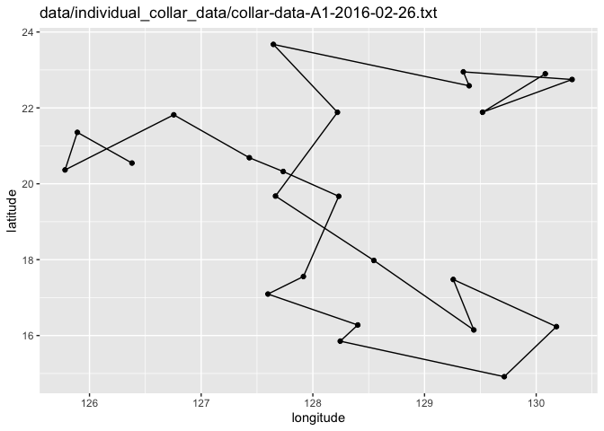

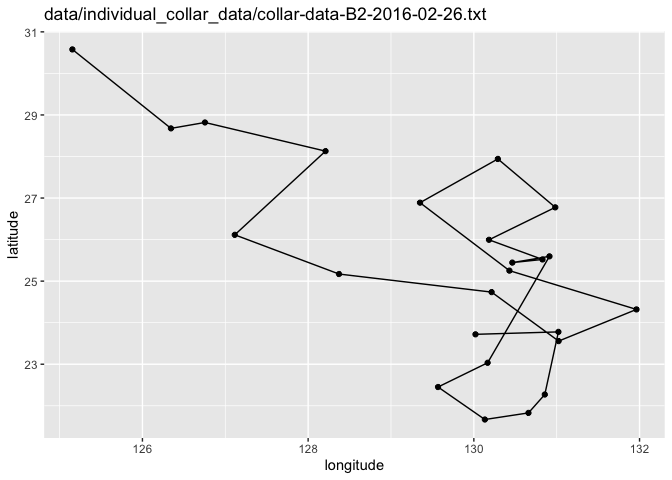

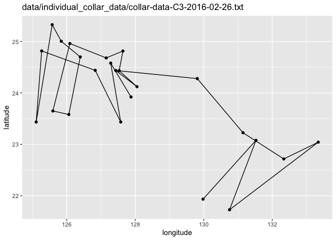

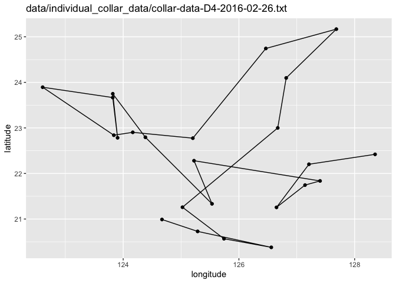

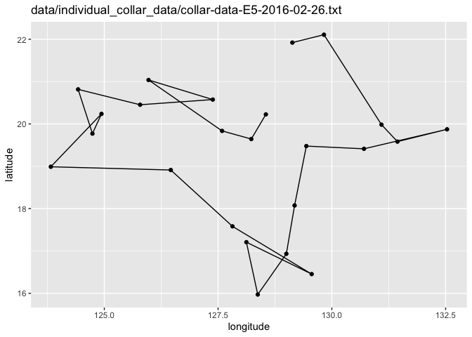

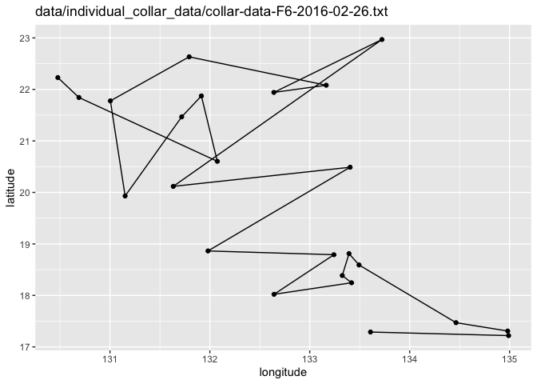

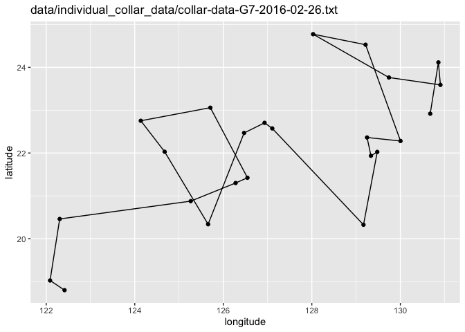

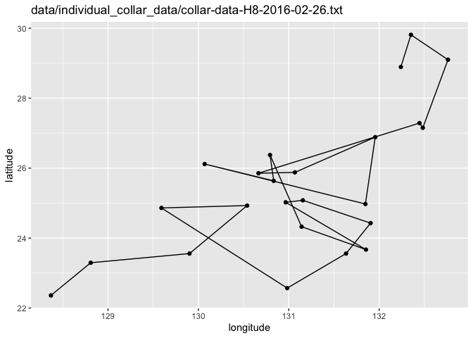

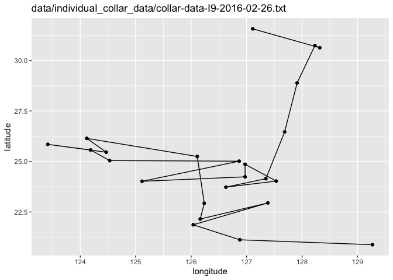

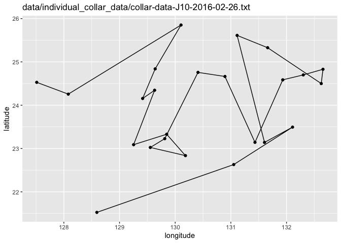

```r
# only ggplot
for (i in 1:length(data_files3)){
  data0 <- as.data.frame(read_csv(data_files3[i]))
  print(
    ggplot(data0, aes(x=long,y=lat))+
      geom_path()+
      geom_point()+
      labs(title = data_files3[i], x = "longitude", y = "latitude")
  )
}
```

```r
# how to show them on a map?

# summary table
data_list <- lapply(data_files3, read_csv)
collar_data_all <- bind_rows(data_list)
collar_data_all %>%
  summarise(max_lat=max(lat),
            min_lat=min(lat),
            max_long=max(long),
            min_long=min(long))
```

```
## # A tibble: 1 x 4
##   max_lat min_lat max_long min_long
##     <dbl>   <dbl>    <dbl>    <dbl>
## 1    31.6    14.9     135.     122.
```

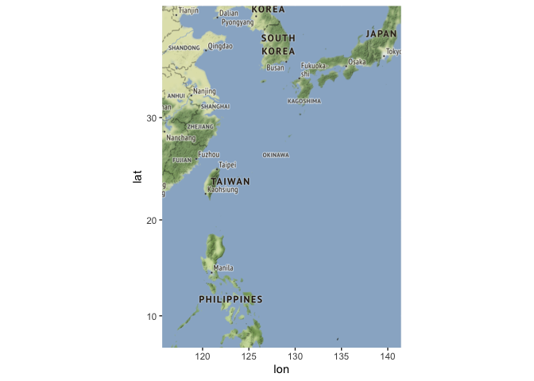

```r
lat <- c(14.91539, 31.56526)
long <- c(122.0874, 134.9906)
bbox <- make_bbox(long, lat, f = 0.5)
map <- get_map(bbox, maptype = "terrain", source = "stamen")
ggmap(map)
```

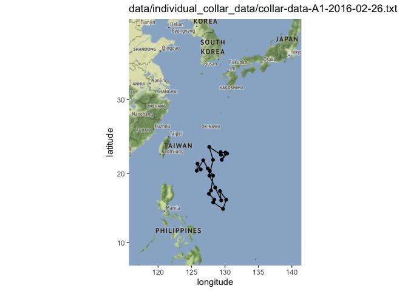

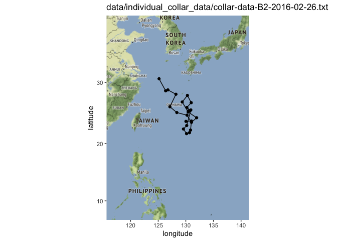

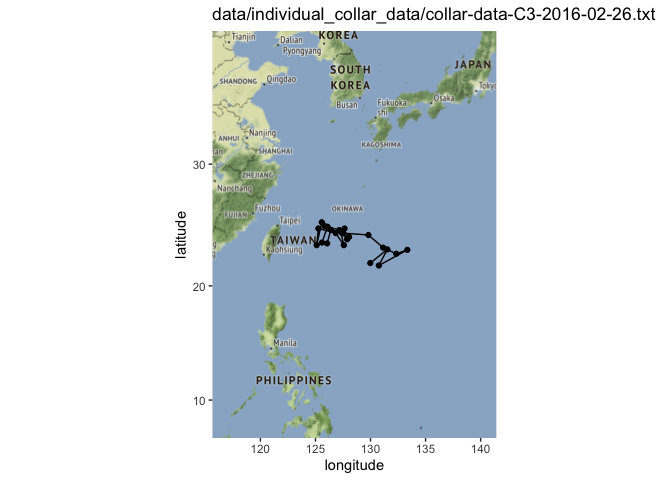

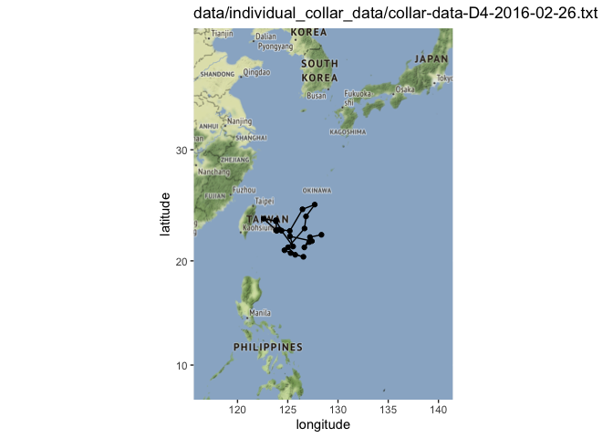

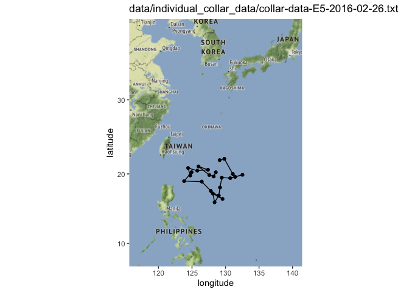

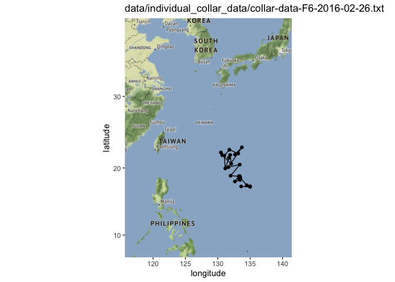

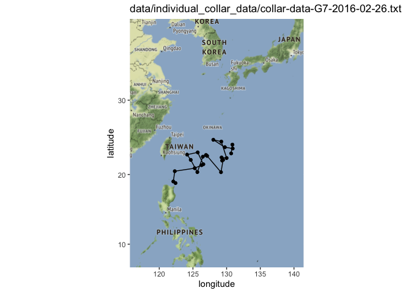

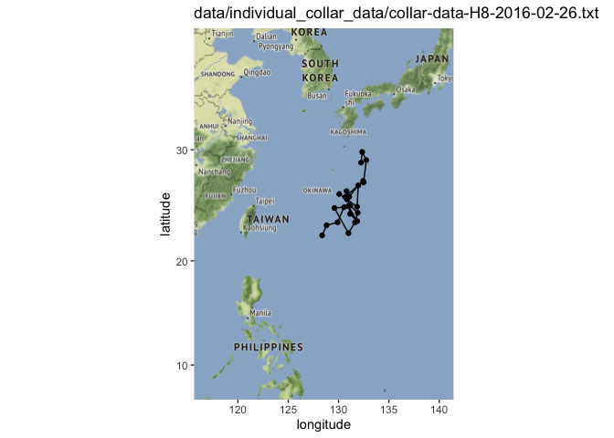

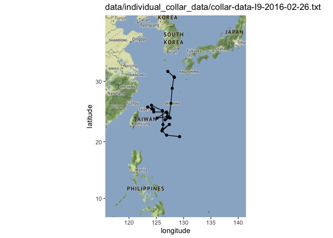

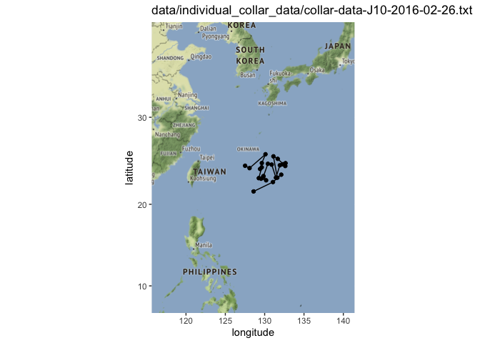

```r
for (i in 1:length(data_files3)){
  data0 <- as.data.frame(read_csv(data_files3[i]))
  print(
    ggmap(map)+
      geom_path(data = data0, aes(long,lat))+
      geom_point(data = data0, aes(long,lat))+
      labs(title = data_files3[i], x = "longitude", y = "latitude")
  )
}
```

### example 4: Looping over files for basic genetic analysis

[Bioconductor](https://www.bioconductor.org/) project is an open source software repository that hosts a wide range of statistical tools developed in the R programming environment. Please use standard R installation procedures to install the BiocManager package and then install “ShortRead” and “Biostrings”.

```r
# if (!requireNamespace("BiocManager", quietly = TRUE))
#     install.packages("BiocManager")
# BiocManager::install()                            # To install core packages or update installed packages
# BiocManager::install(c("ShortRead", "Biostrings"))# Install specific packages
library(ShortRead)
library(Biostrings)
```

The data is downloaded from [PATRIC, BACTERIAL BIOINFORMATICS RESOURCE CENTER](https://patricbrc.org/) The first two lines load a .[fasta](https://en.wikipedia.org/wiki/FASTA_format) file using the ShortRead package in Bioconductor. The second two lines determine the frequency of all of the bases in sequence and then calculate the GC content.

```r
reads <- readFasta("data/archaea-dna/a-saccharovorans.fasta")
seq <- sread(reads)
base_freq <- alphabetFrequency(seq)
gc_content <- (base_freq[1, "G"] + base_freq[1, "C"]) / sum(base_freq) * 100
gc_content
```

```
##        G
## 57.21737
```

Then create a for loop that uses the above code to read in each sequence file and calculate it’s GC content. Store the resulting values in a data frame with one column with file names and a second column with GC contents.

```r
data_files2 <- list.files("data/archaea-dna")
data_files2
```

```
## [1] "A-saccharovorans.fasta" "C-aenigmarchaeum.fasta" "C-lagunensis.fasta"
## [4] "C-symbiosum.fasta"      "F-fontis.fasta"         "G-acetivorans.fasta"
## [7] "H-salinum.fasta"        "N-moolapensis.fasta"    "T-pendens.fasta"
```

```r
GC_results <- data.frame(file_name = vector(mode = "character", length = length(data_files2)),
                         gc_content = vector(mode = "integer", length = length(data_files2)))

for (i in 1:length(data_files2)){
  reads <- readFasta("data/archaea-dna",data_files2[i])
  seq <- sread(reads)
  base_freq <- alphabetFrequency(seq)
  gc_content <- (base_freq[1, "G"] + base_freq[1, "C"]) / sum(base_freq) * 100
  GC_results$file_name[i] <- data_files2[i]
  GC_results$gc_content[i] <- gc_content
}
GC_results
```

```
##                file_name gc_content
## 1 A-saccharovorans.fasta   57.21737
## 2 C-aenigmarchaeum.fasta   39.31925
## 3     C-lagunensis.fasta   30.03402
## 4      C-symbiosum.fasta   57.37338
## 5         F-fontis.fasta   37.47421
## 6    G-acetivorans.fasta   46.84066
## 7        H-salinum.fasta   63.77941
## 8    N-moolapensis.fasta   64.52583
## 9        T-pendens.fasta   57.66566
```

## Packages for next time

Please install packages below for part 2!

```r
#install.packages("qtl")
#install.packages("qtlcharts")
```

## That’s it! Take a break and I will see you on Zoom!

–>[Home](https://jmledford3115.github.io/datascibiol/)